# ProteomicAnalysis_UnwinECandHIPdata

DG

2026-04-17

## #The code below demostrates analysis of protein abundance values for AD and control samples. Proteomic data were obtained from a publicly available Alzheimer’s disease meta-analysis dataset, specifically the Unwin et al. cohort (entorhinal cortex and hippocampus).

## 1.1 Install Packages

install.packages(“BiocManager”)

BiocManager::install(“clusterProfiler”,“limma”,“org.Hs.eg.db”)

install.packages(c(“ggplot2”, “dplyr”, “ggrepel”))

install.packages(“VennDiagram”)

install.packages(“futile.logger”)

install.packages(“pheatmap”)

## 1.2 Load Libraries

library(clusterProfiler)

library(org.Hs.eg.db)

library(dplyr)

library(ggplot2)

library(ggrepel) # Optional but recommended for clean labeling

library(tibble)

library(VennDiagram)

library(grid) library(pheatmap)

## 2. Data Preprocessing

##Load Data

### download data (data17_UnwinHIP_formatted.txt and data18_UnwinEC_formatted.txt) from a github repository (https://github.com/hazhay/Meta-analysis_AD/tree/main/Data)

unwin_ec <- read.delim(“data18_UnwinEC_formatted.txt”, stringsAsFactors = FALSE, check.names = FALSE)

unwin_hip <- read.delim(“data17_UnwinHIP_formatted.txt”, stringsAsFactors = FALSE, check.names = FALSE)

## 2.1. Inspect Data

head(unwin_ec)

dim(unwin_ec)

head(unwin_hip)

dim(unwin_hip)

## 2.2. Check NA levels per sample

colSums(is.na(unwin_ec))

colSums(is.na(unwin_hip))

## 2.3. Check distribution across all samples

boxplot(unwin_ec, las=2, main=“Sample distributions”)

## Sample Distributions EC

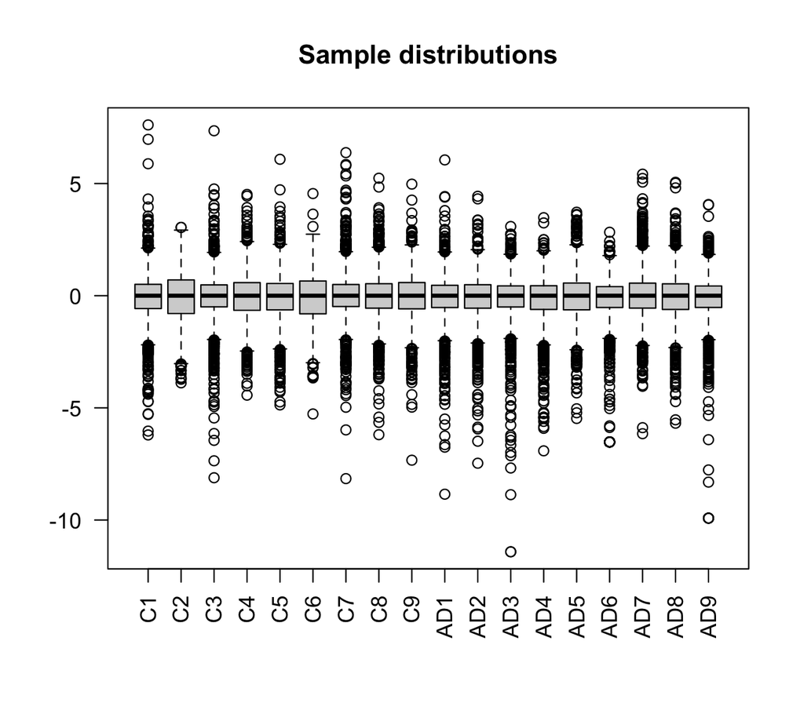

boxplot(unwin_hip, las=2, main=“Sample distributions”)

## Sample Distributions HIP

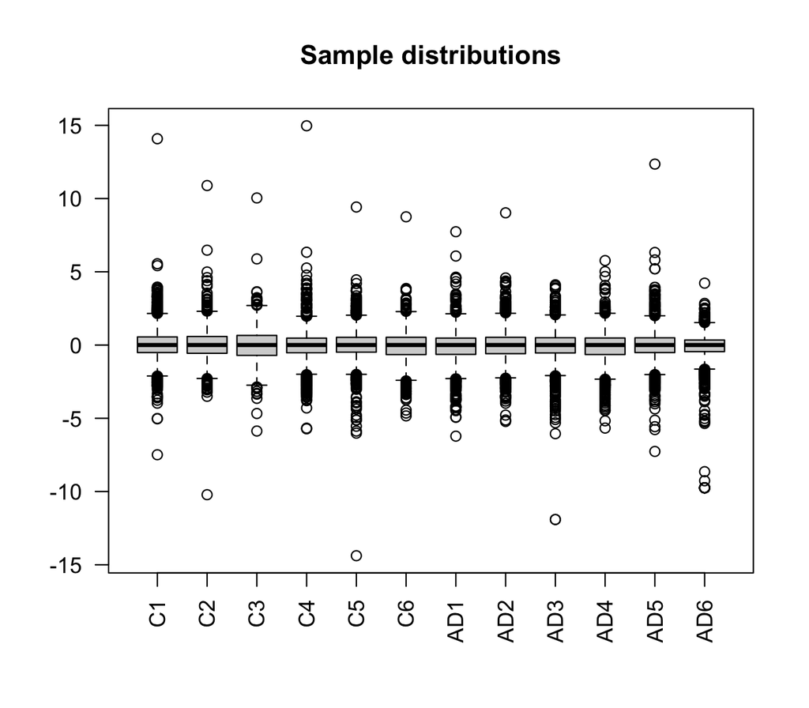

## 2.4. Compare control vs AD – biological check

boxplot(unwin_ec[, group1 == “Control”], unwin_ec[, group1 == “AD”], names=c(“Control”,“AD”))

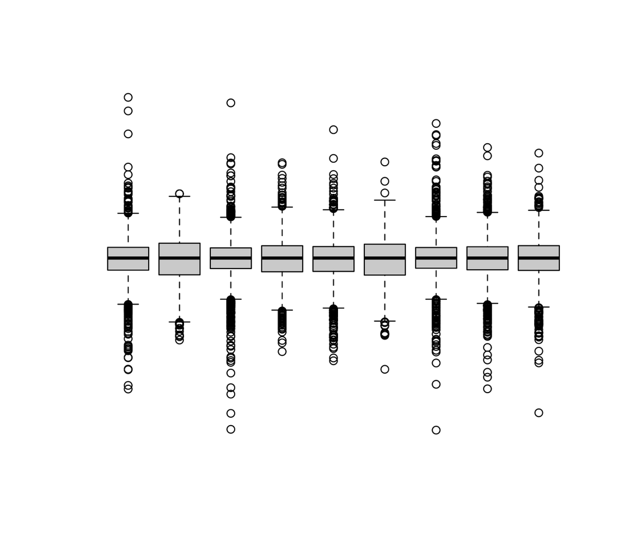

boxplot(unwin_ec[, group2 == “Control”], unwin_ec[, group2 == “AD”], names=c(“Control”,“AD”))

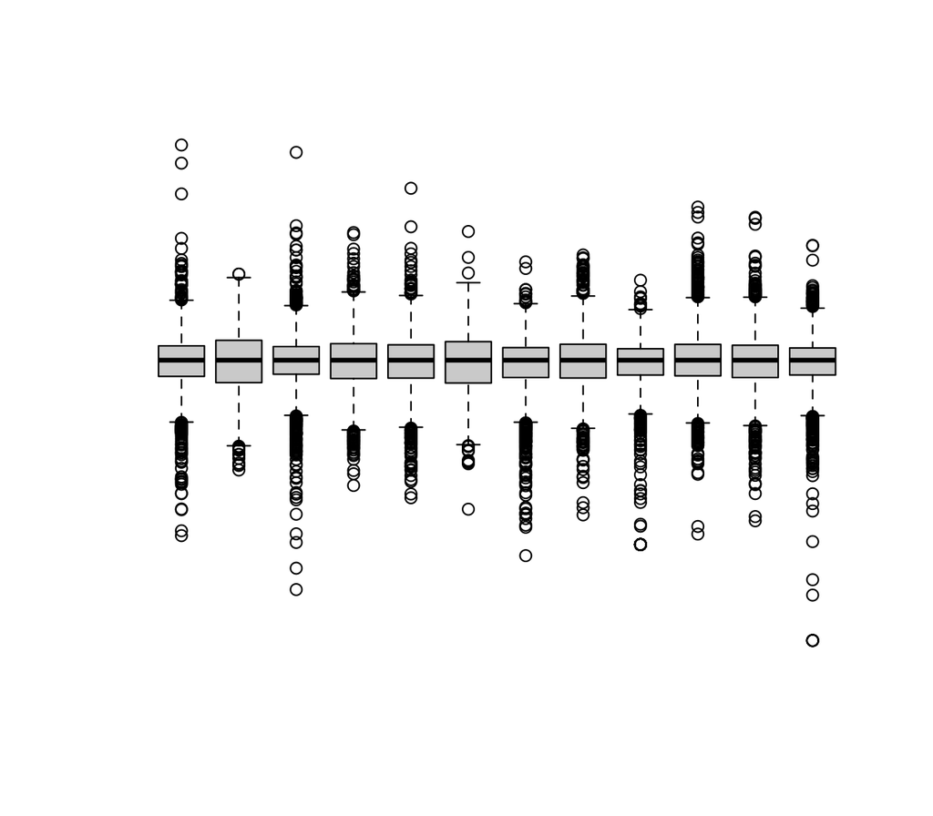

## 2.5. Confirm the raw data structure

readLines(“data18_UnwinEC_formatted.txt”, n = 2)

readLines(“data17_UnwinHIP_formatted.txt”, n = 2)

cat(readLines(“data18_UnwinEC_formatted.txt”, n = 1))

cat(readLines(“data17_UnwinHIP_formatted.txt”, n = 1))

## 2.6.1. Force a strict delimiter parser

unwin_ec <- read.table( “data18_UnwinEC_formatted.txt”, header = TRUE, sep = ““, # auto-detect ANY whitespace stringsAsFactors = FALSE, check.names = FALSE )

unwin_hip <- read.table( “data17_UnwinHIP_formatted.txt”, header = TRUE, sep = ““, # auto-detect ANY whitespace stringsAsFactors = FALSE, check.names = FALSE )

## 2.6.2. Ensure proper grouping

group1 <- ifelse(grepl(“^C”, colnames(unwin_ec)), “Control”, + ifelse(grepl(“^AD”, colnames(unwin_ec)), “AD”, NA))

group2 <- ifelse(grepl(“^C”, colnames(unwin_hip)), “Control”, + ifelse(grepl(“^AD”, colnames(unwin_hip)), “AD”, NA))

## 2.6.3. Verify proper grouping

table(group1)

dim(ec)

length (group1)

table(group2)

dim(hip)

length (group 2)

## 2.7. Run Principal Component Analysis (PCA) - QC step

pca <- prcomp(t(ec), scale.=TRUE)

plot(pca$x[,1], pca$x[,2], col=group1, pch=19, xlab=“PC1”, ylab=“PC2”, main=“PCA - Entorhinal Cortex”)

legend(“topright”, legend=levels(group1), col=1:2, pch=19)

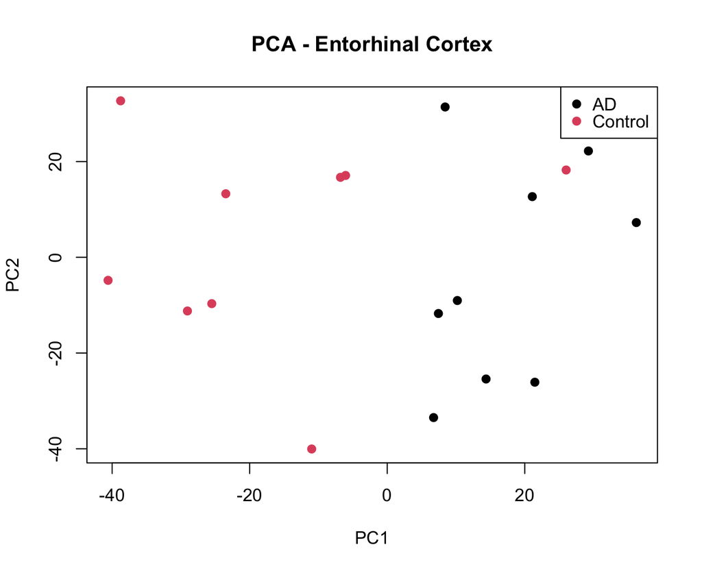

pca <- prcomp(t(hip), scale.=TRUE)

plot(pca$x[,1], pca$x[,2], col=group2, pch=19, xlab=“PC1”, ylab=“PC2”, main=“PCA - Hippocampus”)

legend(“topright”, legend=levels(group2), col=1:2, pch=19)

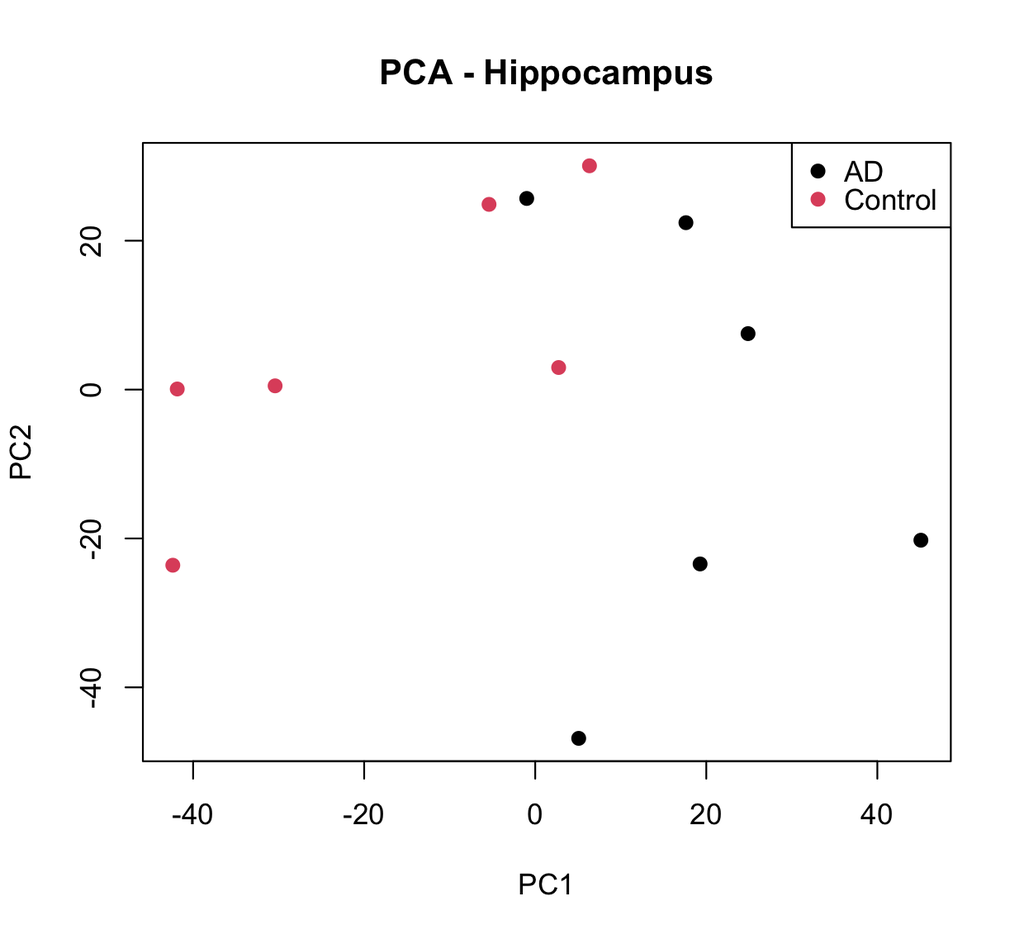

## 3. Limma Analysis

## 3.1. Design matrix

design <- model.matrix(~group1)

design <- model.matrix(~group2)

## 3.2. Fit model

fit <- lmFit(ec, design)

fit <- eBayes(fit)

fit <- lmFit(hip, design)

fit <- eBayes(fit)

## 3.3. Extract Results

results_ec <- topTable(fit, coef=2, number=Inf)

head(results_ec)

results_hip <- topTable(fit, coef=2, number=Inf)

head(results_hip)

## 3.4. Save Results

write.csv(data.frame(Gene = rownames(results), results), “limma_results_ec.csv”, row.names = FALSE)

write.csv(data.frame(Gene = rownames(results), results), “limma_results_hip.csv”, row.names = FALSE)

## 4. Draw plots, graphs and heatmaps

## 4.1. Volcano Plot for EC dataset

results_ec$significant <- results_ec$adj.P.Val < 0.05

ggplot(results_ec, aes(x=logFC, y=-log10(P.Value))) + geom_point(aes(color=significant)) + scale_color_manual(values=c(“grey”, “red”)) + theme_minimal() + ggtitle(“Volcano Plot - EC”)

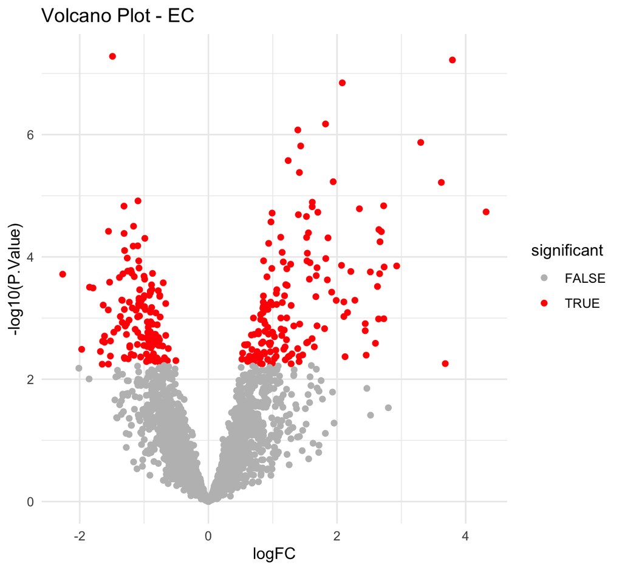

## 4.2. Volcano Plot for HIP dataset

results_hip$significant <- results_hip$adj.P.Val < 0.05

ggplot(results_hip, aes(x=logFC, y=-log10(P.Value))) + geom_point(aes(color=significant)) + scale_color_manual(values=c(“grey”, “blue”)) + theme_minimal() + ggtitle(“Volcano Plot - HIP”)

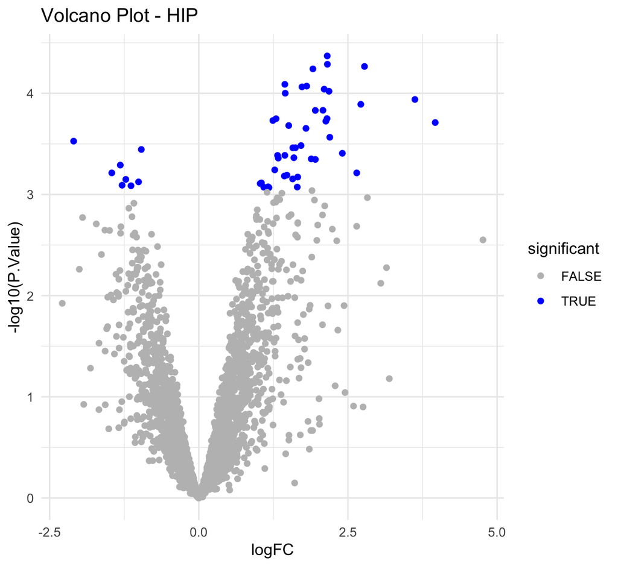

ggplot(results_ec, aes(x = logFC, y = -log10(P.Value))) + geom_point(aes(color = significant)) + geom_text_repel( data = top_genes, aes(label = rownames(top_genes)), size = 3 ) + theme_minimal() + ggtitle(“Volcano Plot - Differentially Abundant Proteins (EC)”)

[figure not shown]

## 4.4. Volcano Plot for HIP dataset – TOP Proteins

ggplot(results_hip, aes(x = logFC, y = -log10(P.Value))) + geom_point(aes(color = significant)) + geom_text_repel( data = top_genes, aes(label = rownames(top_genes)), size = 3 ) + theme_minimal() + ggtitle(“Volcano Plot - Differentially Abundant Proteins (HIP)”)

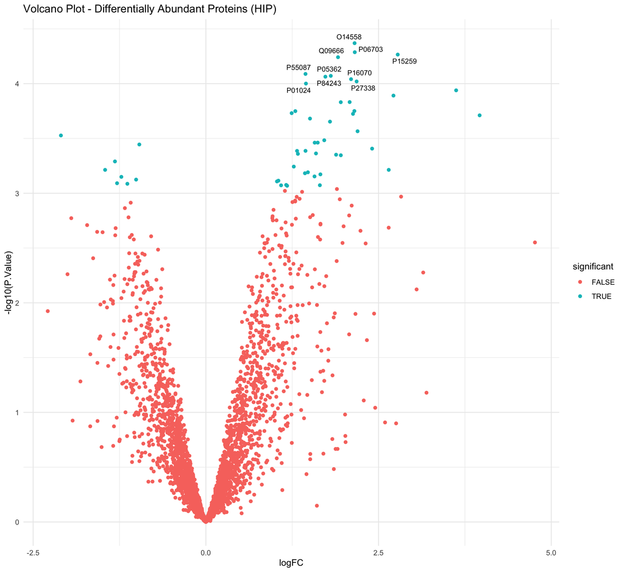